# R Basics Lab

Rob Harbert

5/2/2018

# R Basics

## Outline:

- Setting up on Lyell
- Interactive R - Data I/O refresher, calling functions, libraries, data visualization.
- Vectorizing
- Scripting R
- Defining R functions

## Lyell

We will be working on a teaching cluster maintained by the SICG. You will get printed instructions on how to log in. We have pre-installed most of the R libraries we will need for this course, but where possible I will include installation details for libraries we are using here.

## Interactive R

R is very handy for it’s interactive command line interface. To get started type: ‘R’ at your command line.

What version of R do you have?

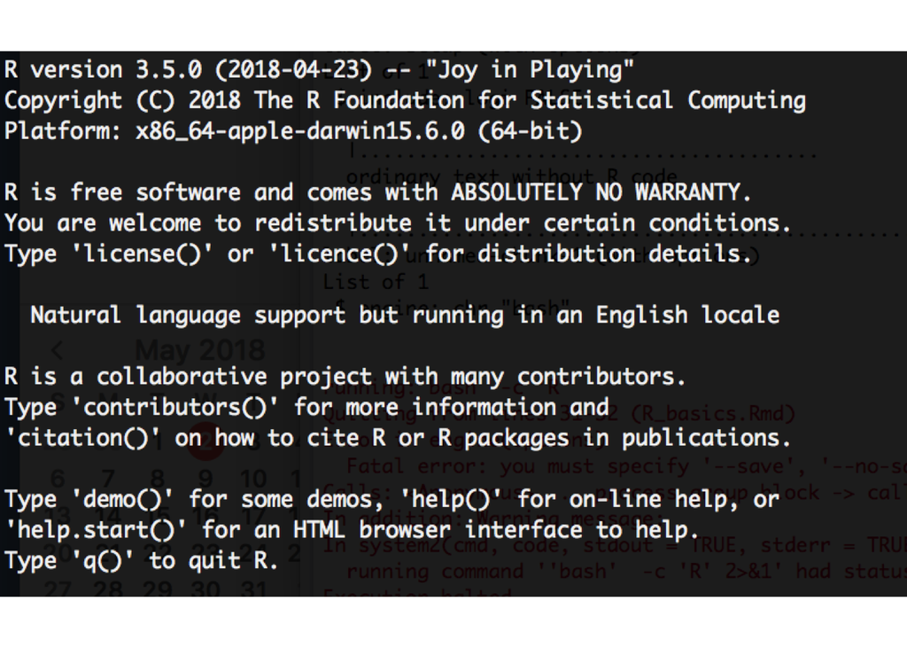

Or

```r
version
```

```
##                _
## platform       x86_64-apple-darwin15.6.0
## arch           x86_64
## os             darwin15.6.0
## system         x86_64, darwin15.6.0
## status
## major          3
## minor          5.0
## year           2018
## month          04
## day            23
## svn rev        74626
## language       R
## version.string R version 3.5.0 (2018-04-23)
## nickname       Joy in Playing
```

We can easily get started with the R command promp open.

```r
x=2
print(x) ##Print method
```

```
## [1] 2
```

```r
class(x)
```

```
## [1] "numeric"
```

```r
x=seq(1:10) # Create a vector
class(x)
```

```
## [1] "integer"
```

```r
print(x)
```

```
##  [1]  1  2  3  4  5  6  7  8  9 10
```

```r
print(x[1]) # First index of vector
```

```
## [1] 1
```

```r
print(x[1:5])
```

```
## [1] 1 2 3 4 5
```

```r
y = matrix(nrow=5, ncol=5) # create a 5x5 matrix
print(y)
```

```
##      [,1] [,2] [,3] [,4] [,5]
## [1,]   NA   NA   NA   NA   NA
## [2,]   NA   NA   NA   NA   NA
## [3,]   NA   NA   NA   NA   NA
## [4,]   NA   NA   NA   NA   NA
## [5,]   NA   NA   NA   NA   NA
```

```r
class(y)
```

```
## [1] "matrix"
```

```r
y[1,1] = 5
print(y)
```

```
##      [,1] [,2] [,3] [,4] [,5]
## [1,]    5   NA   NA   NA   NA
## [2,]   NA   NA   NA   NA   NA
## [3,]   NA   NA   NA   NA   NA
## [4,]   NA   NA   NA   NA   NA
## [5,]   NA   NA   NA   NA   NA
```

```r
y[,1]  = x[1:5]
print(y)
```

```
##      [,1] [,2] [,3] [,4] [,5]
## [1,]    1   NA   NA   NA   NA
## [2,]    2   NA   NA   NA   NA
## [3,]    3   NA   NA   NA   NA
## [4,]    4   NA   NA   NA   NA
## [5,]    5   NA   NA   NA   NA
```

```r
class(y[,1])
```

```
## [1] "numeric"
```

```r
y = cbind(seq(1:5),
          seq(1:5),
          seq(1:5),
          seq(1:5),
          seq(1:5))

class(y)
```

```
## [1] "matrix"
```

## Data I/O

### Shared course data:

Navigate to /data/sp_bio and find the file ebd.csv

Let’s explore this file via some handy Unix command line tools.

```bash
cd /data/sp_bio
ls -l
du -h
head ebd.csv
wc -l ebd.csv
grep "Cardinalis" ebd.csv | wc -l

head -1 ebd.cvs ##look at the column headings.
```

awk is useful for simple scripting and file filtering

```bash
#awk 'conditional { do } '

awk '$7=="New York" { print }'
```

### Read table/tab/csv/txt text files:

read.table() read.csv() read.delim()

```r
cars = read.table('../data/mtcars.csv', header=T, sep = ',') # Read a comma separated values file
head(cars)
```

```
##               model  mpg cyl disp  hp drat    wt  qsec vs am gear carb
## 1         Mazda RX4 21.0   6  160 110 3.90 2.620 16.46  0  1    4    4
## 2     Mazda RX4 Wag 21.0   6  160 110 3.90 2.875 17.02  0  1    4    4
## 3        Datsun 710 22.8   4  108  93 3.85 2.320 18.61  1  1    4    1
## 4    Hornet 4 Drive 21.4   6  258 110 3.08 3.215 19.44  1  0    3    1
## 5 Hornet Sportabout 18.7   8  360 175 3.15 3.440 17.02  0  0    3    2
## 6           Valiant 18.1   6  225 105 2.76 3.460 20.22  1  0    3    1
```

```r
cars = read.csv('../data/mtcars.csv')
cars = read.csv2('../data/mtcars.csv') ## Interesting behavior here, will be somewhat faster

cars = read.delim('../data/mtcars.csv', sep=',')
```

fread - Faster read

```r
library(data.table)
ebd = fread('../data/ebd_trim2.csv', sep = '\t')
```

## Loops

Repeating tasks using for loops

```r
for(i in 1:10) {
  print(i)
}
```

```
## [1] 1
## [1] 2
## [1] 3
## [1] 4
## [1] 5
## [1] 6
## [1] 7
## [1] 8
## [1] 9
## [1] 10
```

Catch loop output

```r
li = vector()
for(i in 1:10){
  li[[i]]=log(i)
}
```

## apply family functions

The Apply functions in R provide efficient repetition that usually out-performs for loops.

```r
print(y) #our matrix from earlier
```

```
##      [,1] [,2] [,3] [,4] [,5]
## [1,]    1    1    1    1    1
## [2,]    2    2    2    2    2
## [3,]    3    3    3    3    3
## [4,]    4    4    4    4    4
## [5,]    5    5    5    5    5
```

```r
y = as.data.frame(y)
li1 = apply(y, 1, log) # row-wise
li2 = apply(y, 2, log) # column-wise

li2 = lapply(y[,1], log) #returns list
#li2 = vapply(y[,1], log) #returns list
```